# Agrupamento

Michel Fiorio

2023-08-04

# Cálculos de medidas de proximidades (similaridade ou dissimilaridade)

# Métodos para variáveis quantitativas

```r
# Conjunto de dados exemplo:

dados <- matrix(c(9.6, 28, 18, 8.4, 31, 16, 2.4, 42, 9, 18.2, 38, 20, 3.9, 25, 12), 5, 3, TRUE)
```

## Distância Euclidiana quadrática

- usa-se matriz identidade
- aplicada para dados de mesma escala
- função ‘dist()’

```r
euclidiana <- dist(dados, method = "euclidean")^2
euclidiana
```

```
##        1      2      3      4
## 2  14.44
## 3 328.84 206.00
## 4 177.96 161.04 386.64
## 5  77.49  72.25 300.25 437.49
```

```r
euclidiana <- dist(dados, method = "euclidean", diag = TRUE, upper = TRUE)^2
euclidiana
```

```
##        1      2      3      4      5
## 1   0.00  14.44 328.84 177.96  77.49
## 2  14.44   0.00 206.00 161.04  72.25
## 3 328.84 206.00   0.00 386.64 300.25
## 4 177.96 161.04 386.64   0.00 437.49
## 5  77.49  72.25 300.25 437.49   0.00
```

## Criando a função para cálculo das distâncias de Karl Pearson e Mahalanobis

```r
generalizada.dist <- function(data.x, data.y=NULL, vc=NULL){
  xx <- as.matrix(data.x)
  if(is.null(data.y))
    yy <- as.matrix(data.x)
  else
    yy <- as.matrix(data.y)
  if(is.null(vc)){
    if(is.null(data.y))
      vc <- var(xx)
    else
      vc <- var(rbind(xx,yy))
  }
  ny <- nrow(yy)
  md <- matrix(0,nrow(xx), ny)
  for(i in 1:ny){
    md[,i] <- mahalanobis(xx, yy[i,], cov=vc)
  }
  if(is.null(data.y))
    dimnames(md) <- list(rownames(data.x), rownames(data.x))
  else
    dimnames(md) <- list(rownames(data.x), rownames(data.y))
  sqrt(md)
}
```

## Distância euclidiana padronizada quadrática (Karl Pearson)

- matriz diagonal da variância dos dados
- aplicada para dados de diferentes escalas e desconsidera correlação entre as variáveis
- usa a função ‘generalizada.dist’ criada acima

```r
a <-var(dados)
D <-diag(diag(a))
D <-as.matrix(D)
karl_pearson<-(generalizada.dist(dados,vc=D))^2
karl_pearson
```

```
##          [,1]     [,2]      [,3]      [,4]      [,5]
## [1,] 0.000000 0.418567  9.342959  4.137111  2.826740
## [2,] 0.418567 0.000000  5.821620  4.285655  2.051415
## [3,] 9.342959 5.821620  0.000000 12.869589  6.323453
## [4,] 4.137111 4.285655 12.869589  0.000000 11.922891
## [5,] 2.826740 2.051415  6.323453 11.922891  0.000000
```

## Distância de Mahalanobis

- matriz de covariância dos dados
- aplicada para dados de diferentes escalas e com correlação entre as variáveis
- usa a função ‘generalizada.dist’ criada acima

```r
mahalanobis <- generalizada.dist(dados,vc=a)^2
mahalanobis
```

```
##           [,1]      [,2]     [,3]     [,4]     [,5]
## [1,] 0.0000000 0.5349336 7.369240 7.031932 7.074218
## [2,] 0.5349336 0.0000000 4.244065 4.943367 4.866917
## [3,] 7.3692402 4.2440650 0.000000 7.964014 7.971785
## [4,] 7.0319318 4.9433675 7.964014 0.000000 7.999528
## [5,] 7.0742180 4.8669170 7.971785 7.999528 0.000000
```

## Método de agrupamento hierárquico

- Produzir uma árvore de classificação, chamada dendrograma
- Os individuos são classificados em grupos e os pontos de junção dos grupos são as distâncias euclidianas entre os grupos
- Critério do vizinho mais próximo ou ligação simples: A distância entre dois grupos é dada por: d(rs)(tu) = mínimo{drt; dru; dst; dsu}
- Critério do vizinho mais distante ou ligação completa: A distância entre dois grupos é dada por: d(rs)(tu) = máximo{drt; dru; dst; dsu}
- Critério da ligação média (UPGMA): A distÂncia entre dois grupos é dada pela média da distância dos pares de individuos

```r
# Aplicação prática usando a matriz 'dados' e a matriz resultante da distância 'euclidiana'

par(mfrow = c(2,2))
agr1<-hclust(euclidiana, method = "single")
agr1$height   # Mostra os pontos de fusão do agrupamento
```

```
## [1]  14.44  72.25 161.04 206.00
```

```r
agr1 <- as.dendrogram(agr1)
plot(agr1,xlab="",ylab="Distância Euclidiana Quadrática",main="Método do vizinho mais próximo")

agr2<-hclust(euclidiana, method = "complete")
agr2$height #pontos de fusão.
```

```
## [1]  14.44  77.49 328.84 437.49
```

```r
agr2 <- as.dendrogram(agr2)
plot(agr2, xlab=" ",ylab="Distância Euclidiana Quadrática",main="Método do vizinho mais distante")

agr3<-hclust(euclidiana, method = "average")
agr3$height #pontos de fusão.
```

```
## [1]  14.4400  74.8700 258.8300 305.4325
```

```r
agr3 <- as.dendrogram(agr3)
plot(agr3, xlab=" ",ylab="Distância Euclidiana Quadrática",main="UPGMA")

agr4<-hclust(euclidiana, method ="ward.D")
agr4$height #pontos de fusão.
```

```
## [1]  14.44000  95.01333 360.88167 394.62500
```

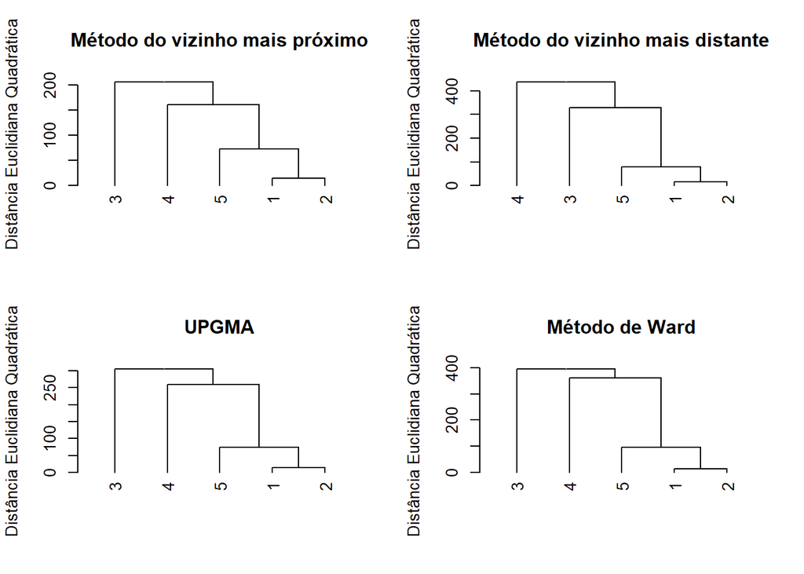

```r
agr4 <- as.dendrogram(agr4)
plot(agr4, xlab=" ",ylab="Distância Euclidiana Quadrática",main="Método de Ward")
```

## Método de agrupamento hierárquico no banco de dados Iris

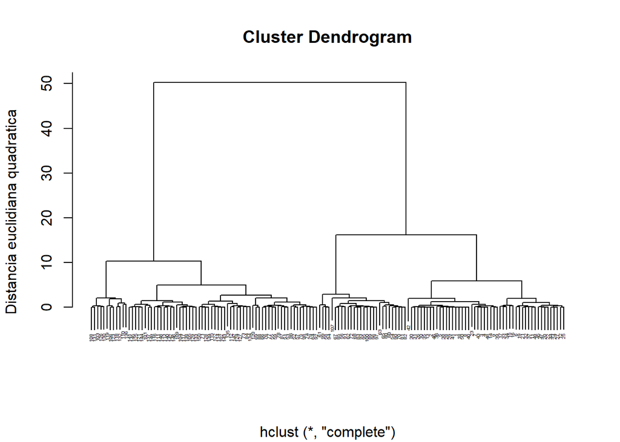

```r
#Aplicação prática usando o banco de dados 'IRIS'

dados_iris <- iris

eucli_iris <- dist(dados_iris[,-5], method = "euclidean")^2

agrupamento = hclust(eucli_iris, method = "complete")

plot(agrupamento, xlab = "", ylab = "Distancia euclidiana quadratica", cex = 0.3)
```

```r
# Correlação cofenética do resultado com os dados originais

cofenetica = cophenetic(agrupamento)
cor(cofenetica, eucli_iris)
```

```
## [1] 0.6427609
```

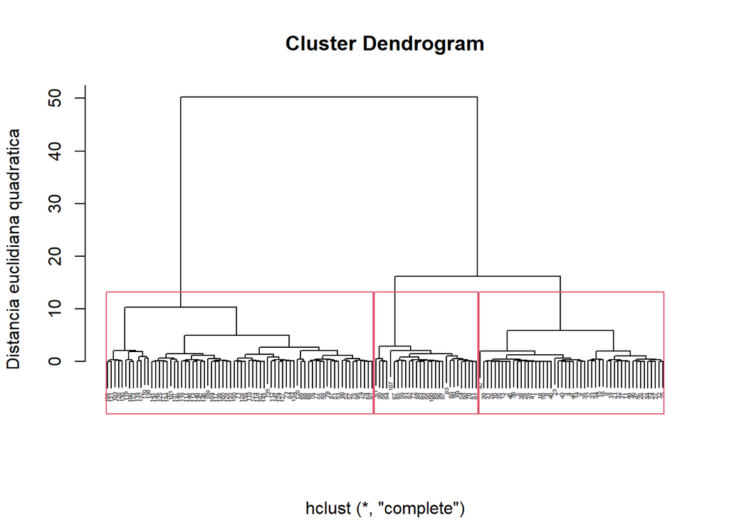

```r
# adiciona retangulos ao redor dos grupos
plot(agrupamento, xlab = "", ylab = "Distancia euclidiana quadratica", cex = 0.3)
rect.hclust(agrupamento, k = 3)
```

```r
# Mostrando os grupos em que os dados estão contidos
grupos <- cutree(agrupamento, k = 3)
grupos
```

```
##   [1] 1 1 1 1 1 1 1 1 1 1 1 1 1 1 1 1 1 1 1 1 1 1 1 1 1 1 1 1 1 1 1 1 1 1 1 1 1
##  [38] 1 1 1 1 1 1 1 1 1 1 1 1 1 2 2 2 3 2 3 2 3 2 3 3 3 3 2 3 2 3 3 2 3 2 3 2 2
##  [75] 2 2 2 2 2 3 3 3 3 2 3 2 2 2 3 3 3 2 3 3 3 3 3 2 3 3 2 2 2 2 2 2 3 2 2 2 2
## [112] 2 2 2 2 2 2 2 2 2 2 2 2 2 2 2 2 2 2 2 2 2 2 2 2 2 2 2 2 2 2 2 2 2 2 2 2 2
## [149] 2 2
```

## Método de agrupamento não hierárquico

## Método K-médias. Minimizar a distância de elementos dentro de grupos.

- Define-se a quantidade de grupos e o critério para as sementes.

```r
# Aplicação prática usando a matriz 'dados':

agr<-kmeans(dados, centers= 2)
agr
```

```
## K-means clustering with 2 clusters of sizes 4, 1
##
## Cluster means:
##     [,1] [,2] [,3]
## 1 10.025 30.5 16.5
## 2  2.400 42.0  9.0
##
## Clustering vector:
## [1] 1 1 2 1 1
##
## Within cluster sum of squares by cluster:
## [1] 235.1675   0.0000
##  (between_SS / total_SS =  45.6 %)
##
## Available components:
##
## [1] "cluster"      "centers"      "totss"        "withinss"     "tot.withinss"
## [6] "betweenss"    "size"         "iter"         "ifault"
```

```r
agr$cluster
```

```
## [1] 1 1 2 1 1
```

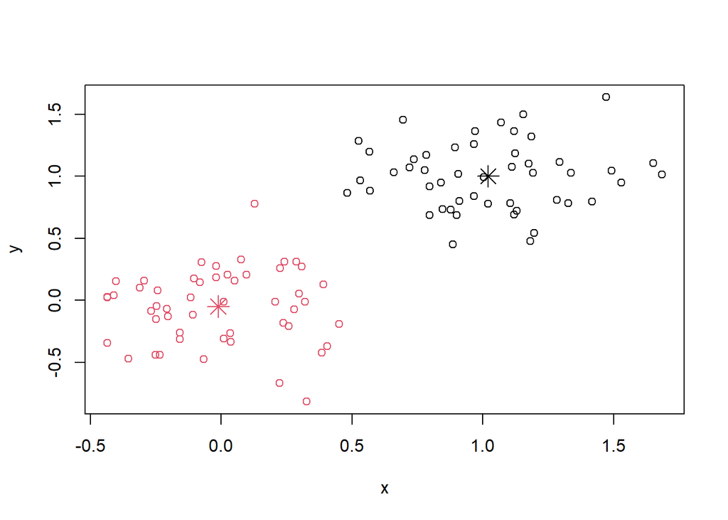

```r
# Aplicação prática usando uma matriz aleatória 'x'

x <- rbind(matrix(rnorm(100, mean=0, sd = 0.3), ncol = 2),matrix(rnorm(100, mean = 1, sd = 0.3), ncol= 2))
colnames(x) <- c("x", "y")
cluster <- kmeans(x, 2)
plot(x,col=cluster$cluster)
points(cluster$centers,col=1:2,pch=8,cex=2) #pch=formato; cex=tamanho
```

```r
# Aplicação pratica usando os dados 'IRIS'

kmedia = kmeans(dados_iris[,-5], 3, nstart = 20)
kmedia
```

```
## K-means clustering with 3 clusters of sizes 50, 62, 38
##
## Cluster means:
##   Sepal.Length Sepal.Width Petal.Length Petal.Width
## 1     5.006000    3.428000     1.462000    0.246000
## 2     5.901613    2.748387     4.393548    1.433871
## 3     6.850000    3.073684     5.742105    2.071053
##
## Clustering vector:
##   [1] 1 1 1 1 1 1 1 1 1 1 1 1 1 1 1 1 1 1 1 1 1 1 1 1 1 1 1 1 1 1 1 1 1 1 1 1 1
##  [38] 1 1 1 1 1 1 1 1 1 1 1 1 1 2 2 3 2 2 2 2 2 2 2 2 2 2 2 2 2 2 2 2 2 2 2 2 2
##  [75] 2 2 2 3 2 2 2 2 2 2 2 2 2 2 2 2 2 2 2 2 2 2 2 2 2 2 3 2 3 3 3 3 2 3 3 3 3
## [112] 3 3 2 2 3 3 3 3 2 3 2 3 2 3 3 2 2 3 3 3 3 3 2 3 3 3 3 2 3 3 3 2 3 3 3 2 3
## [149] 3 2
##
## Within cluster sum of squares by cluster:
## [1] 15.15100 39.82097 23.87947
##  (between_SS / total_SS =  88.4 %)
##
## Available components:
##
## [1] "cluster"      "centers"      "totss"        "withinss"     "tot.withinss"
## [6] "betweenss"    "size"         "iter"         "ifault"
```

```r
kmedia$cluster
```

```
##   [1] 1 1 1 1 1 1 1 1 1 1 1 1 1 1 1 1 1 1 1 1 1 1 1 1 1 1 1 1 1 1 1 1 1 1 1 1 1
##  [38] 1 1 1 1 1 1 1 1 1 1 1 1 1 2 2 3 2 2 2 2 2 2 2 2 2 2 2 2 2 2 2 2 2 2 2 2 2
##  [75] 2 2 2 3 2 2 2 2 2 2 2 2 2 2 2 2 2 2 2 2 2 2 2 2 2 2 3 2 3 3 3 3 2 3 3 3 3
## [112] 3 3 2 2 3 3 3 3 2 3 2 3 2 3 3 2 2 3 3 3 3 3 2 3 3 3 3 2 3 3 3 2 3 3 3 2 3
## [149] 3 2
```